# Week 06 - Genetic Algorithm Assignment

**In this assignment, we will be applying the genetic algorithm approach for solving a problem involving locations of healthcare facilities. “Mo_pop_Sim.zip”, contains simulated data of the residential locations of (assumed) residents of Missouri. And “MO_2018_Federally_Qualified_Health_Center_Locations.zip” contains data on FQHCs. Our goal is to identify, from the list of FQHCs, a set of 8 FQHCs where we can provide specialized mental health services. Assume that none of FQHCs present in the data currently have these services, and that we are identifying 8 locations where these services would be introduced for the first time.**

```r
#Clearing environment
rm(list = ls())
```

```r
#Importing SF library, rgdal library was deprecated in 2023 by CRAN
if(!library("sf", logical.return = TRUE)){
  install.packages("sf")}
library("sf")
```

```r
#Importing the shape file from the folder
fqhc_sp <- st_read("MO_2018_Federally_Qualified_Health_Center_Locations")
```

```r
#Checking type of data after importing
class(fqhc_sp)
```

```
[1] "sf"         "data.frame"
```

```r
#Checking description of the data
summary(fqhc_sp)
```

```
    OBJECTID    Group_Name          Facility           Address              City              County
 Min.   :  1   Length:197         Length:197         Length:197         Length:197         Length:197
 1st Qu.: 50   Class :character   Class :character   Class :character   Class :character   Class :character
 Median : 99   Mode  :character   Mode  :character   Mode  :character   Mode  :character   Mode  :character
 Mean   : 99
 3rd Qu.:148
 Max.   :197
    State               Zip               Phone              Latitude       Longitude        Loc_Code
 Length:197         Length:197         Length:197         Min.   :36.23   Min.   :-95.24   Length:197
 Class :character   Class :character   Class :character   1st Qu.:37.21   1st Qu.:-93.80   Class :character
 Mode  :character   Mode  :character   Mode  :character   Median :38.44   Median :-92.43   Mode  :character
                                                          Mean   :38.24   Mean   :-92.24
                                                          3rd Qu.:39.06   3rd Qu.:-90.43
                                                          Max.   :40.44   Max.   :-89.39
          geometry
 POINT        :197
 epsg:4326    :  0
 +proj=long...:  0
```

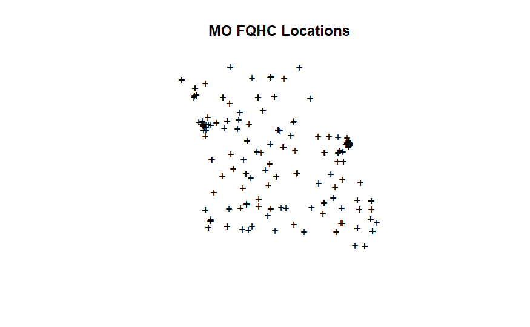

```r
#Plotting all the locations of FQHC with the map view
plot(fqhc_sp$geometry, pch = "+", col = "black", main = "MO FQHC Locations")
```

```r
#Importing the residential dataset of Missouri
pop_df <-read.csv("Mo_pop_Sim.csv")
```

```r
library(dplyr) #Importing dplyr
set.seed(100)
pop_sample <- pop_df %>% sample_n(6334) #As this dataset contains more than 6 million data points, therefore we are sampling it to only 6334 random samples
pop_sf <- st_as_sf(pop_sample, coords = c("long", "lat"), crs = 4326) #For better accessibility, we are converting the dataframe to sf.
```

```r
if(!library("geosphere", logical.return = TRUE)){
  install.packages("geosphere")} #We need this package to compute the geo-spatial distance between two locations.
library("geosphere")
if(!library("GA", logical.return = TRUE)){
  install.packages("GA")} #Importing Genetic algorithm package to be able to fit GA models
library("GA")
```

```r
count_residences_within_radius <- function(geom, residences, radius = 48280) {
  #This fitness function is going to find all the residences within 30 miles (48280 meters) for the established FQHC that will be passed during the function call, and it's going to return that number back to the main function.
  distances <- distGeo(st_coordinates(geom), st_coordinates(residences))  # Compute distances
  return(sum(distances <= radius))  # Count residences within radius
}
```

**Assumptions: Two possible assumptions for this method are, 1. The best locations are where the most people can access services easily. 2. It assumes a 30-mile radius is a reasonable travel distance for healthcare access.**

**Fitness function : Each FQHC location contributes to the total fitness based on the number of residents it serves within a 30-mile (48,280-meter) radius. The greater the total number of residents served, the better the solution.**